# Workshop 01. Foundations of Data Science

KiraRoberts

2026-06-03

## Introduction

When handling large amounts of data as professionals, a clean environment is just as important as clean data. Clearing our our environment before every session can show us where issues lie within our coding.

### Clear out environment

```r
# Housekeeping
## Inventory every active object currently residing in session RAM
objects()
```

```
## character(0)
```

```r
## Purge global environment
rm(list = ls())
# Confirm that global session memory now completely vacant
objects()
```

```
## character(0)
```

### Load packages

```r
library(tidyverse)
```

### Source script

The following was used to call up the code found in the script “Workshop1.R”.

```r
# Set the source as the script file "Workshop1.R"
source("Workshop1.R")
```

For the sake of this portfolio, I have copied the code into this markdown chunk.

```r
# Load the primary data science framework and Excel import library
library(tidyverse)
library(readxl)
library(here)

# Practice Import A: Loading a standard comma-separated plain text file
benthic_cover <- read_csv(here::here("../data/reef_cover_log.csv"))

# Practice Import B: Parsing a tab-separated telemetry instrument array string
acoustic_stream <- read_tsv(here::here("../data/acoustic_telemetry_stream.txt"))

# Practice Import C: Targeting a specific sheet in a multi-tab Excel spreadsheet
fisheries_annual <- read_excel(here::here("../data/fish_catch_data.xlsx"), sheet = "Commercial_2026")

# Read in mangrove_data
mangrove_data <- read_csv(file = here::here("../data/mangrove_survey_raw.csv"))
# Reading in this dataset created an issue as the first 5 lines are formatted differently, they appear to contain the meta data. This meta data then sets the format for the following data, setting it in a single column.

# Use args within read_csv to skip headers and declare missing flags
mangrove_data <- read_csv(
  here::here("../data/mangrove_survey_raw.csv"),
  skip = 5,   # Skip the first 5 lines of field notes
  na = c(".", "NA", "9999", "ND", "blank"))  # Convert known text alts to true NA

#------------------------------------------------------------------

# Force a modern tibble to degrade into a legacy base R data frame structure
benthic_cover_df <- as.data.frame(benthic_cover)


# Print the old-style dataframe structure to view
print(benthic_cover_df)
```

```
##        site_id transect_no       date depth_m hard_coral_pct macroalgae_pct
## 1    Nelly_Bay           1 2026-05-10     4.5           45.2           12.1
## 2    Nelly_Bay           2 2026-05-10     5.1           38.5           15.4
## 3 Geoffrey_Bay           1 2026-05-11     3.8           52.1            8.3
## 4 Geoffrey_Bay           2 2026-05-11     4.2           48.9           10.2
## 5 Florence_Bay           1 2026-05-12     6.0           61.3            5.1
## 6 Florence_Bay           2 2026-05-12     5.8           58.7            6.4
##   bare_substrate_pct
## 1               42.7
## 2               46.1
## 3               39.6
## 4               40.9
## 5               33.6
## 6               34.9
```

```r
# And compare with tibble alternative
print(benthic_cover)
```

```
## # A tibble: 6 × 7
##   site_id      transect_no date       depth_m hard_coral_pct macroalgae_pct
##   <chr>              <dbl> <date>       <dbl>          <dbl>          <dbl>
## 1 Nelly_Bay              1 2026-05-10     4.5           45.2           12.1
## 2 Nelly_Bay              2 2026-05-10     5.1           38.5           15.4
## 3 Geoffrey_Bay           1 2026-05-11     3.8           52.1            8.3
## 4 Geoffrey_Bay           2 2026-05-11     4.2           48.9           10.2
## 5 Florence_Bay           1 2026-05-12     6             61.3            5.1
## 6 Florence_Bay           2 2026-05-12     5.8           58.7            6.4
## # ℹ 1 more variable: bare_substrate_pct <dbl>
```

```r
#-----------------------------------------------------------------

# Install the data package (execute this command once in your console pane and then delete!)
#install.packages("palmerpenguins")

# Load the package data into active memory
library(palmerpenguins)
data("penguins")

# Examine the structure of the dataset - always do this when loading a new dataset!
glimpse(penguins) # tidyverse version (from dplyr package)
```

```
## Rows: 344
## Columns: 8
## $ species           <fct> Adelie, Adelie, Adelie, Adelie, Adelie, Adelie, Adel…
## $ island            <fct> Torgersen, Torgersen, Torgersen, Torgersen, Torgerse…
## $ bill_length_mm    <dbl> 39.1, 39.5, 40.3, NA, 36.7, 39.3, 38.9, 39.2, 34.1, …
## $ bill_depth_mm     <dbl> 18.7, 17.4, 18.0, NA, 19.3, 20.6, 17.8, 19.6, 18.1, …
## $ flipper_length_mm <int> 181, 186, 195, NA, 193, 190, 181, 195, 193, 190, 186…
## $ body_mass_g       <int> 3750, 3800, 3250, NA, 3450, 3650, 3625, 4675, 3475, …
## $ sex               <fct> male, female, female, NA, female, male, female, male…
## $ year              <int> 2007, 2007, 2007, 2007, 2007, 2007, 2007, 2007, 2007…
```

```r
str(penguins) # base R version
```

```
## tibble [344 × 8] (S3: tbl_df/tbl/data.frame)
##  $ species          : Factor w/ 3 levels "Adelie","Chinstrap",..: 1 1 1 1 1 1 1 1 1 1 ...
##  $ island           : Factor w/ 3 levels "Biscoe","Dream",..: 3 3 3 3 3 3 3 3 3 3 ...
##  $ bill_length_mm   : num [1:344] 39.1 39.5 40.3 NA 36.7 39.3 38.9 39.2 34.1 42 ...
##  $ bill_depth_mm    : num [1:344] 18.7 17.4 18 NA 19.3 20.6 17.8 19.6 18.1 20.2 ...
##  $ flipper_length_mm: int [1:344] 181 186 195 NA 193 190 181 195 193 190 ...
##  $ body_mass_g      : int [1:344] 3750 3800 3250 NA 3450 3650 3625 4675 3475 4250 ...
##  $ sex              : Factor w/ 2 levels "female","male": 2 1 1 NA 1 2 1 2 NA NA ...
##  $ year             : int [1:344] 2007 2007 2007 2007 2007 2007 2007 2007 2007 2007 ...
```

```r
# Generate an exploratory summary matrix
summary(penguins)
```

```
##       species          island    bill_length_mm  bill_depth_mm
##  Adelie   :152   Biscoe   :168   Min.   :32.10   Min.   :13.10
##  Chinstrap: 68   Dream    :124   1st Qu.:39.23   1st Qu.:15.60
##  Gentoo   :124   Torgersen: 52   Median :44.45   Median :17.30
##                                  Mean   :43.92   Mean   :17.15
##                                  3rd Qu.:48.50   3rd Qu.:18.70
##                                  Max.   :59.60   Max.   :21.50
##                                  NA's   :2       NA's   :2
##  flipper_length_mm  body_mass_g       sex           year
##  Min.   :172.0     Min.   :2700   female:165   Min.   :2007
##  1st Qu.:190.0     1st Qu.:3550   male  :168   1st Qu.:2007
##  Median :197.0     Median :4050   NA's  : 11   Median :2008
##  Mean   :200.9     Mean   :4202                Mean   :2008
##  3rd Qu.:213.0     3rd Qu.:4750                3rd Qu.:2009
##  Max.   :231.0     Max.   :6300                Max.   :2009
##  NA's   :2         NA's   :2
```

```r
#-----------------------------------------------------------------

# Vertically slice specific morphometric variables by explicit name
morphology_metrics <- select(penguins, species, bill_length_mm, bill_depth_mm, body_mass_g)
glimpse(morphology_metrics)
```

```
## Rows: 344
## Columns: 4
## $ species        <fct> Adelie, Adelie, Adelie, Adelie, Adelie, Adelie, Adelie,…
## $ bill_length_mm <dbl> 39.1, 39.5, 40.3, NA, 36.7, 39.3, 38.9, 39.2, 34.1, 42.…
## $ bill_depth_mm  <dbl> 18.7, 17.4, 18.0, NA, 19.3, 20.6, 17.8, 19.6, 18.1, 20.…
## $ body_mass_g    <int> 3750, 3800, 3250, NA, 3450, 3650, 3625, 4675, 3475, 425…
```

```r
# Retain a continuous block of attributes using the colon operator
spatial_block <- select(penguins, species:island)

# Discard logistics tracking attributes while preserving everything else using the minus sign
clean_scientific_fields <- select(penguins, -year)


#-----------------------------------------------------------------

# Isolate observations belonging to a single categorical target group
adelie_cohort <- filter(penguins, species == "Adelie")

# Sift out individuals using continuous numerical boundary thresholds
# Preserves only large penguins whose mass exceeds 4500 grams
heavy_penguins <- filter(penguins, body_mass_g > 4500)

# Combine multiple conditional parameters across separate attributes
# Preserves records matching Gentoo penguins sampled explicitly on Biscoe Island
biscoe_gentoo <- filter(penguins, species == "Gentoo" & island == "Biscoe")

# Sift records matching multiple targeting flags within an explicit set
sub_islands <- filter(penguins, island %in% c("Dream", "Torgersen"))


#----------------------------------------------------------------

# Sort penguins by ascending body mass (Default setting: Smallest mass first)
lightest_first <- arrange(penguins, body_mass_g)

# Sort penguins in descending sequence using the desc() layout wrapper
heaviest_first <- arrange(penguins, desc(body_mass_g))

# Execute nested sorting criteria: Group by species, then sort by descending bill length
stratified_morphology <- arrange(penguins, species, desc(bill_length_mm))


#----------------------------------------------------------------
## Pipes
#Instead of:
penguins_subset <- mutate(penguins, bill_ratio = bill_length_mm / bill_depth_mm)
penguins_final <- filter(penguins_subset, species == "Adelie")

#You can simply write:
penguins_final <- penguins %>%
  mutate(bill_ratio = bill_length_mm / bill_depth_mm) %>%
  filter(species == "Adelie")

#----------------------------------------------------------------
# Mutate

# Calculate a new morphological ratio in our environment
penguin_ratios <- penguins  |>
  mutate(body_mass_kg = body_mass_g / 1000,   # Convert grams to kilograms
         bill_ratio = bill_length_mm / bill_depth_mm  # Bill ratio
  )

# View your newly engineered variables appended to the far-right columns
glimpse(penguin_ratios)
```

```
## Rows: 344
## Columns: 10
## $ species           <fct> Adelie, Adelie, Adelie, Adelie, Adelie, Adelie, Adel…
## $ island            <fct> Torgersen, Torgersen, Torgersen, Torgersen, Torgerse…
## $ bill_length_mm    <dbl> 39.1, 39.5, 40.3, NA, 36.7, 39.3, 38.9, 39.2, 34.1, …
## $ bill_depth_mm     <dbl> 18.7, 17.4, 18.0, NA, 19.3, 20.6, 17.8, 19.6, 18.1, …
## $ flipper_length_mm <int> 181, 186, 195, NA, 193, 190, 181, 195, 193, 190, 186…
## $ body_mass_g       <int> 3750, 3800, 3250, NA, 3450, 3650, 3625, 4675, 3475, …
## $ sex               <fct> male, female, female, NA, female, male, female, male…
## $ year              <int> 2007, 2007, 2007, 2007, 2007, 2007, 2007, 2007, 2007…
## $ body_mass_kg      <dbl> 3.750, 3.800, 3.250, NA, 3.450, 3.650, 3.625, 4.675,…
## $ bill_ratio        <dbl> 2.090909, 2.270115, 2.238889, NA, 1.901554, 1.907767…
```

```r
#----------------------------------------------------------------

# Grouping our active memory penguins by species
grouped_penguins <- group_by(penguins, species)

# Notice that the table looks identical, but metadata notes 'Groups: species [3]'
print(grouped_penguins)
```

```
## # A tibble: 344 × 8
## # Groups:   species [3]
##    species island    bill_length_mm bill_depth_mm flipper_length_mm body_mass_g
##    <fct>   <fct>              <dbl>         <dbl>             <int>       <int>
##  1 Adelie  Torgersen           39.1          18.7               181        3750
##  2 Adelie  Torgersen           39.5          17.4               186        3800
##  3 Adelie  Torgersen           40.3          18                 195        3250
##  4 Adelie  Torgersen           NA            NA                  NA          NA
##  5 Adelie  Torgersen           36.7          19.3               193        3450
##  6 Adelie  Torgersen           39.3          20.6               190        3650
##  7 Adelie  Torgersen           38.9          17.8               181        3625
##  8 Adelie  Torgersen           39.2          19.6               195        4675
##  9 Adelie  Torgersen           34.1          18.1               193        3475
## 10 Adelie  Torgersen           42            20.2               190        4250
## # ℹ 334 more rows
## # ℹ 2 more variables: sex <fct>, year <int>
```

```r
# Collapsing the buckets into explicit summary metrics
species_mass_summary <- summarise(grouped_penguins,
                                  mean_mass_g = mean(body_mass_g)
)

print(species_mass_summary)
```

```
## # A tibble: 3 × 2
##   species   mean_mass_g
##   <fct>           <dbl>
## 1 Adelie            NA
## 2 Chinstrap       3733.
## 3 Gentoo            NA
```

```r
# Overcoming the missing value trap using na.rm = TRUE
biological_signal <- penguins %>%
  group_by(species, sex) %>%
  summarise(
    sample_size = n(),    # Count total individuals per category
    mean_mass_g = mean(body_mass_g, na.rm = TRUE), # Calculate mean ignoring missing cells
    sd_mass_g   = sd(body_mass_g, na.rm = TRUE)  # Standard deviation calculation
  )

print(biological_signal) #the species will have a group that gives an NA for sex - i believe this is to count those samples that have an NA for sex
```

```
## # A tibble: 8 × 5
## # Groups:   species [3]
##   species   sex    sample_size mean_mass_g sd_mass_g
##   <fct>     <fct>        <int>       <dbl>     <dbl>
## 1 Adelie    female          73       3369.      269.
## 2 Adelie    male            73       4043.      347.
## 3 Adelie    <NA>             6       3540       477.
## 4 Chinstrap female          34       3527.      285.
## 5 Chinstrap male            34       3939.      362.
## 6 Gentoo    female          58       4680.      282.
## 7 Gentoo    male            61       5485.      313.
## 8 Gentoo    <NA>             5       4588.      338.
```

```r
#----------------------------------------------------------------
```

## Challenge: Visualizing Body Size and Shape

*Using your loaded data, create a code chunk in your .qmd that performs the following two tasks side-by-side:* *1. Summary Table: Pipe your data to group_by() and summarise() to calculate the mean body mass for each species and island.* *Visualisation: Pipe the same dataset into ggplot() to create a boxplot of body_mass_g by species, with the island variable mapped to fill or facet_wrap().*

```r
# Summary
penguins %>%
  group_by(species, island) %>%
  summarise(mean(body_mass_g, na.rm = TRUE))
```

```
## # A tibble: 5 × 3
## # Groups:   species [3]
##   species   island    `mean(body_mass_g, na.rm = TRUE)`
##   <fct>     <fct>                                 <dbl>
## 1 Adelie    Biscoe                                3710.
## 2 Adelie    Dream                                 3688.
## 3 Adelie    Torgersen                             3706.
## 4 Chinstrap Dream                                 3733.
## 5 Gentoo    Biscoe                                5076.
```

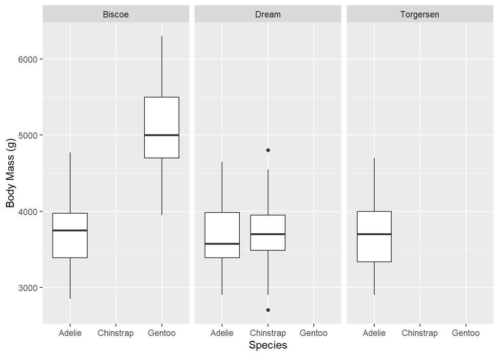

```r
# Visualization
penguins %>%
  ggplot(aes(x = species, y = body_mass_g)) +
    geom_boxplot() +
  facet_wrap(~ island) +
  labs(x = "Species", y = "Body Mass (g)")
```

## Challenge: Piping Directly to Visualization

*In your .qmd template, try creating a new plot. Experiment with swapping sd_mass (standard deviation) for standard error—you will need to divide your sd by the square root of n (sd / sqrt(n)). See how that changes your visual interpretation of the data uncertainty. Present the summary table alongside the associated figure and write down your thoughts on the underlying ecological story that the data are telling.*

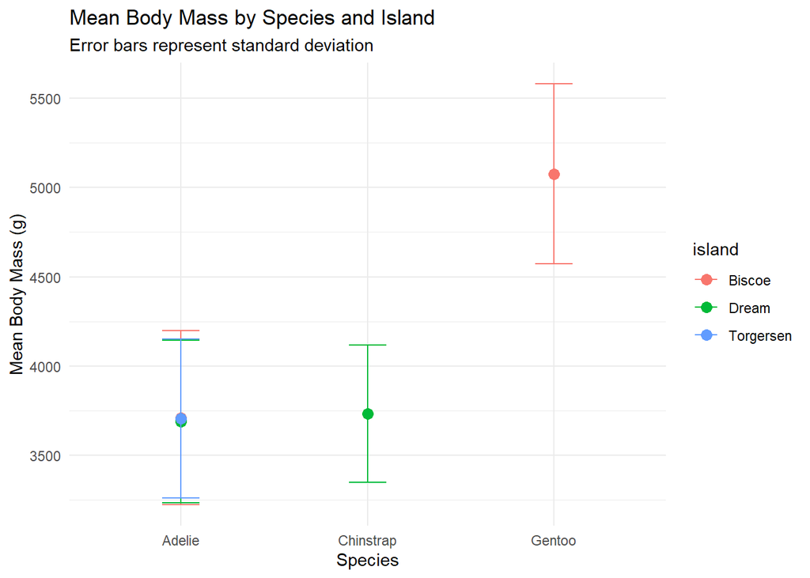

```r
# Pipe directly from aggregation to plotting with error bars
mass_compare_plot <- penguins %>%
  group_by(species, island) %>%
  summarise(
    mean_mass = mean(body_mass_g, na.rm = TRUE),
    sd_mass = sd(body_mass_g, na.rm = TRUE),
    n = n(),
    .groups = "drop"
  ) %>%
  ggplot(aes(x = species, y = mean_mass, colour = island)) +
  geom_point(size = 3) +
  geom_errorbar(aes(ymin = mean_mass - sd_mass,
                    ymax = mean_mass + sd_mass),
                width = 0.2) +
  labs(title = "Mean Body Mass by Species and Island",
       subtitle = "Error bars represent standard deviation",
       y = "Mean Body Mass (g)",
       x = "Species") +
  theme_minimal()

mass_compare_plot
```

Even knowing nothing about the biology of these penguin, it is hard to argue that the vast difference in masses between Gentoo penguins and Adelie and Chinstrap penguins, is likely a result of growth difference. Assuming penguins grow to a maximum size and then stop, and their mass is directly associated with this size, it is clear that the Gentoo penguins must grow to a larger maximum size than the other two species.

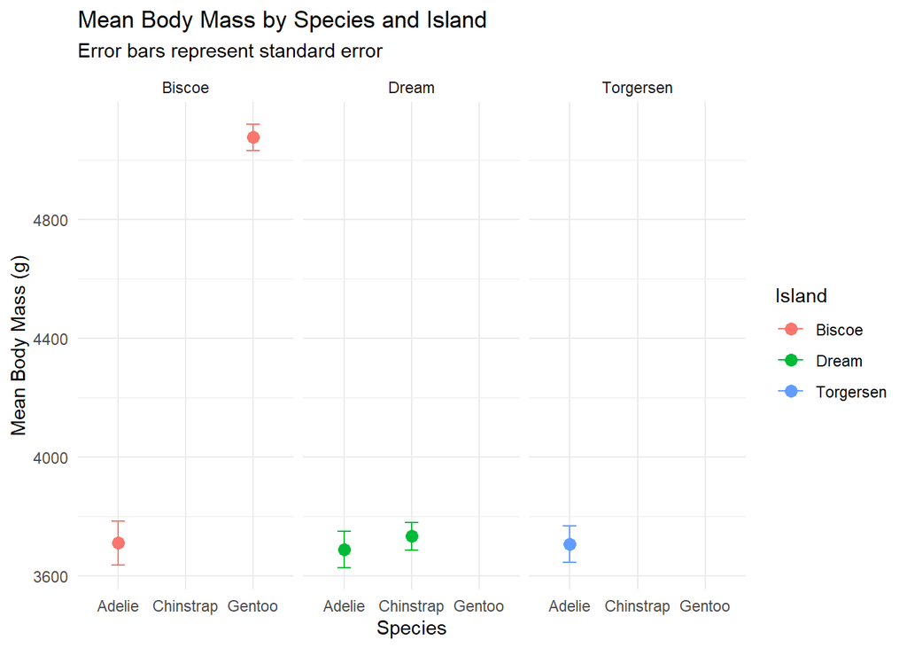

```r
SEmass_compare_plot <- penguins %>%
  group_by(species, island) %>%
  summarise(
    n = n(),
    mean_mass = mean(body_mass_g, na.rm = TRUE),
    se_mass = (sd(body_mass_g, na.rm = TRUE))/sqrt(n),
    .groups = "drop"
  ) %>%
  ggplot(aes(x = species, y = mean_mass, colour = island)) +
  geom_point(size = 3, position = position_dodge()) +
  geom_errorbar(aes(ymin = mean_mass - se_mass,
                    ymax = mean_mass + se_mass),
                position = position_dodge(),
                width = 0.2) +
  facet_wrap(~ island) +
  labs(title = "Mean Body Mass by Species and Island",
       subtitle = "Error bars represent standard error",
       colour = "Island",
       y = "Mean Body Mass (g)",
       x = "Species") +
  theme_minimal()

SEmass_compare_plot
```

```r
if (!dir.exists("../outputs/figures")) dir.create("../outputs/figures") # folder for figs
```